# Qual local faz o melhor Miojinho?

Tuts

2021-03-17

## Pacotes

```r
library(knitr) #rmarkdown
library(tidyverse) #pacotes dos deuses
library(sf) #mapas e geoshit
library(spdep) #geoshit
library(ggrepel) # legendas com repel no ggplot
library(scales) #escalas
library(FSA) #testes de hipóteses
```

## Leitura e preparação dos dados

```r
ramen <- read_csv("ramen-ratings.csv")
```

- Já da para notar que a coluna `Stars` foi lida como string, isso é por conta de ter algumas linhas com `Unrated`. Caso use o `as.numeric()` esses casos viram `NA` e da tudo certo.

```r
ramen %>%
  glimpse()
```

```
## Rows: 2,580
## Columns: 7
## $ `Review #` <dbl> 2580, 2579, 2578, 2577, 2576, 2575, 2574, 2573, 2572, 2571…
## $ Brand      <chr> "New Touch", "Just Way", "Nissin", "Wei Lih", "Ching's Sec…
## $ Variety    <chr> "T's Restaurant Tantanmen", "Noodles Spicy Hot Sesame Spic…
## $ Style      <chr> "Cup", "Pack", "Cup", "Pack", "Pack", "Pack", "Cup", "Tray…
## $ Country    <chr> "Japan", "Taiwan", "USA", "Taiwan", "India", "South Korea"…
## $ Stars      <chr> "3.75", "1", "2.25", "2.75", "3.75", "4.75", "4", "3.75", …
## $ `Top Ten`  <chr> NA, NA, NA, NA, NA, NA, NA, NA, NA, NA, NA, NA, NA, NA, NA…
```

```r
ramen <-
  ramen %>%
  mutate(Stars = as.numeric(Stars))
```

- Agregar informação geográfica.

```r
mapa_mundo <- read_sf("mapa_mundi.geojson")
```

- É preciso corrigir alguns nomes para dar “match”.

```r
mapa_mundo_fix <-
  mapa_mundo %>%
  select(continent, name_long) %>%
  mutate(Country = case_when(name_long == "Republic of Korea" ~ "South Korea",
                             name_long == "United Kingdom" ~ "UK",
                             name_long == "United States" ~ "USA",
                             T ~ name_long))

geo_ramen <-
  ramen %>%
  mutate(Country = case_when(Country == "Holland" ~ "Netherlands",
                             Country == "Dubai" ~ "United Arab Emirates",
                             Country == "Hong Kong" ~ "China",
                             Country == "Singapore" ~ "Malaysia",
                             Country == "Sarawak" ~ "Malaysia",
                             Country == "United States" ~ "USA",
                             T ~ Country)) %>%
  left_join(mapa_mundo_fix) %>%
  st_as_sf()
```

## Análise

### Quantidade de amostras por país.

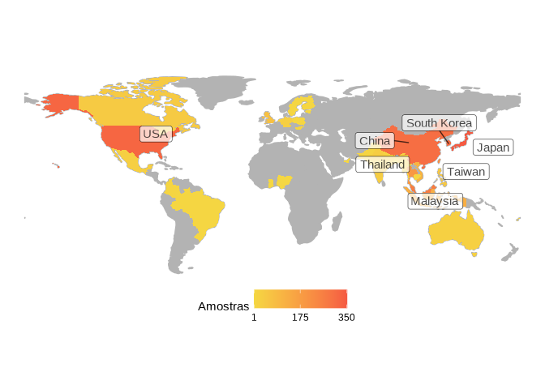

```r
geo_ramen %>%
  count(Country) %>%
  mutate(label = ifelse(n>quantile(n, .8), Country, NA)) %>%
  ggplot() +
  geom_sf(data = mapa_mundo_fix, fill = "grey70", col = "grey70") +
  geom_sf(aes(fill = n), col = NA) +
  geom_label_repel(aes(label = label, geometry = geometry),
                   stat = "sf_coordinates",
                   col = 1, alpha = .7) +
  theme_void() +
  theme(legend.position = "bottom") +
  scale_fill_gradient("Amostras", low = "#f5d742", high = "#f55a42",
                      breaks = c(1, 175, 350))
```

- Nota-se que há uma grande concentração das amostras entre os países da Ásia, sobretudo na China, Coreia do Sul e Japão. Outro país com grande quantidade é os EUA. Vê-se também que a África não possui muitos representantes.

### Quantidade de amostras por continente.

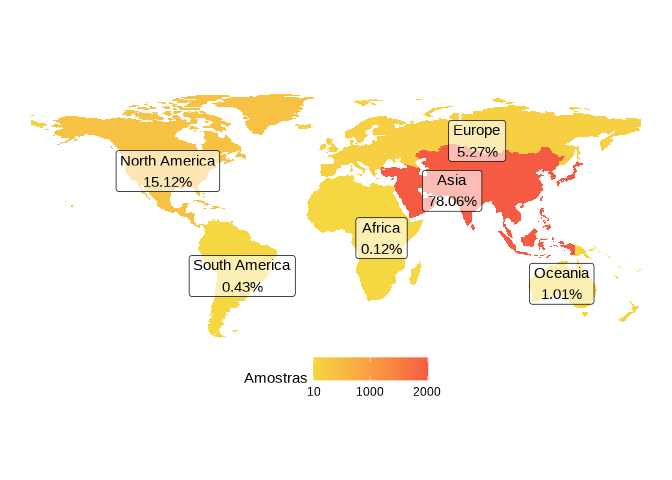

```r
geo_ramen %>%
  count(continent) %>%
  st_drop_geometry() %>%
  left_join(count(mapa_mundo_fix, continent) %>% select(-n)) %>%
  mutate(pct = n/sum(n),
         pct = percent(pct, accuracy = .01),
         lb = paste0(continent,"\n", pct)) %>%
  st_as_sf() %>%
  ggplot() +
  geom_sf(aes(fill=n), col=NA) +
  geom_sf_label(aes(label = lb), alpha = .6) +
  theme_void() +
  theme(legend.position = "bottom") +
  scale_fill_gradient("Amostras", low = "#f5d742", high = "#f55a42",
                      breaks = c(10, 1000, 2000))
```

- É possível ver que a Ásia possui aproximadamente 78% de todas as amostras, sendo o continente com mais marcas avaliadas disparadamente. O pŕoximo continente da lista é a América do Norte, com 15%. África e América do Sul tem uma representatividade menor que 1% no total de miojos.

### Média de Score por país

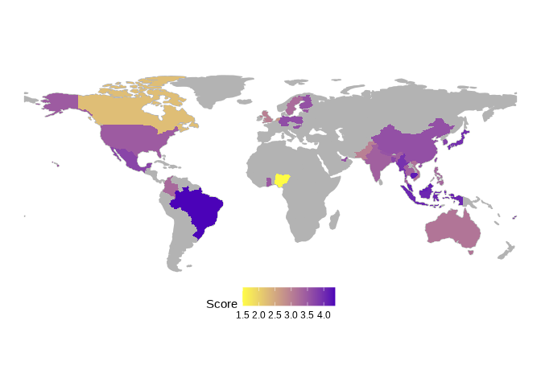

```r
geo_ramen %>%
  group_by(Country) %>%
  summarise(score = mean(Stars, na.rm = T)) %>%
  ggplot() +
  geom_sf(data = mapa_mundo_fix, fill = "grey70", col = "grey70") +
  geom_sf(aes(fill = score), col = NA) +
  theme_void() +
  theme(legend.position = "bottom") +
  scale_fill_gradient("Score", low = "#fffc45", high = "#4b02b8")
```

### Média de Score por continente

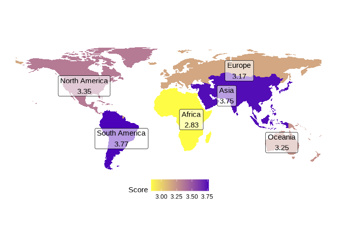

```r
geo_ramen %>%
  group_by(continent) %>%
  summarise(score = mean(Stars, na.rm = T)) %>%
  st_drop_geometry() %>%
  left_join(count(mapa_mundo_fix, continent) %>% select(-n)) %>%
  mutate(lb = paste0(continent,"\n",
                     round(score, 2))) %>%
  st_as_sf() %>%
  ggplot() +
  geom_sf(aes(fill=score), col=NA) +
  geom_sf_label(aes(label = lb), alpha = .6) +
  theme_void() +
  theme(legend.position = "bottom") +
  scale_fill_gradient("Score", low = "#fffc45", high = "#4b02b8")
```

### Existe correlaçao espacial na qualidade dos miojos?

- Para responder isso será utilizado o índice I de Moran, uma medida de correlação espacial que varia de -1 a 1.
- Primeiro é preciso criar a “vizinhança” de cada país.

```r
vizinhos <-
  geo_ramen %>%
  group_by(Country) %>%
  summarise(score = mean(Stars, na.rm = T)) %>%
  poly2nb(.,
          queen=TRUE) #opcao para dizer que nao precisa "encostar"
```

- Agora é preciso criar “pesos” para cada vizinhança, no caso será usado o método mais simples que assume pesos iguais `style = W`.

```r
vizinhos_peso <- nb2listw(vizinhos,
                          style="W",
                          zero.policy=TRUE) #permitir regiões sem vizinhança
```

- Teste de hipótese e coeficiente I de Moran.

> Hipótese nula: Não existe correlação espacial (I=0)

```r
geo_ramen %>%
  group_by(Country) %>%
  summarise(score = mean(Stars, na.rm = T)) %>%
  pull(score) %>%
  moran.mc(., vizinhos_peso, zero.policy = T, nsim = 10000, alternative = "less")
```

```
##
##  Monte-Carlo simulation of Moran I
##
## data:  .
## weights: vizinhos_peso
## number of simulations + 1: 10001
##
## statistic = -0.018542, observed rank = 5077, p-value = 0.5076
## alternative hypothesis: less
```

- Como o valor-p é alto (0.5) e a estatística é próxima de 0, não há evidências de correlação espacial em relação ao score. :(

### Existe diferença significativa entre as qualidades dos miojos entre os continentes?

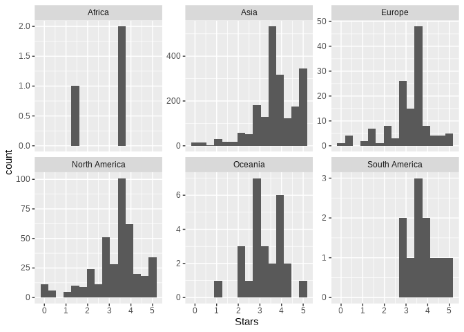

```r
geo_ramen %>%
  ggplot(aes(Stars)) +
  geom_histogram(bins = 15) +
  facet_wrap(~continent, scales = "free_y")
```

- Como o comportamento da variável score é assimétrica e estranha primeiramente vou usar o teste não paramétrico de Kruskal–Wallis para testar se ao menos 1 continente difere dos demais. As hipóteses do teste são:

> Hipótese nula: não existe efeito do continente no score

> Hipótese alternativa: existe efeito do continente no score

```r
kruskal.test(Stars ~ continent, data = geo_ramen)
```

```
##
##  Kruskal-Wallis rank sum test
##
## data:  Stars by continent
## Kruskal-Wallis chi-squared = 101.21, df = 5, p-value < 2.2e-16
```

- Como o valor-p foi praticamente 0, rejeita-se a hipótese de que os scores não diferem de acordo com o continente.
- Como sabemos que pelo menos algum continente difere dos demais, é preciso testar par a par a fim de entender quem difere de quem. Para isso, usei o teste de Dunn para comparações múltiplas.
- Tentativa de gráfico para comparações múltiplas:

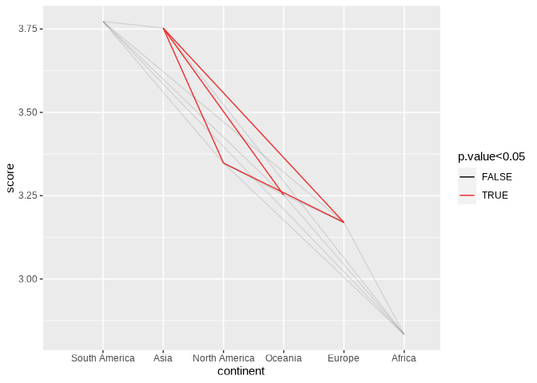

```r
resultado_dunn <-
  dunnTest(Stars ~ continent,
        data=geo_ramen,
        method="bh")

resultado_dunn$res %>%
  mutate(p.value = round(P.adj,4)) %>%
  select(Comparison, p.value) %>%
  mutate(sig = p.value < .05,
         Comparison = as.character(Comparison),
         group = Comparison) %>%
  separate(Comparison, into = c("C1", "C2"), sep = " - ") %>%
  gather("ordem", "continent", -c(p.value,sig,group)) %>%
  left_join(geo_ramen %>%
              group_by(continent) %>%
              summarise(score = mean(Stars, na.rm = T)) %>%
              st_drop_geometry()) %>%
  arrange(desc(score)) %>%
  mutate(continent = factor(continent, unique(continent))) %>%
  ggplot(aes(continent, score, group = group, col = sig)) +
  geom_line(aes(alpha = ifelse(sig, 1, .8)), show.legend = F) +
  geom_line(aes(x = 0, y = min(score))) +
  scale_color_manual("p.value<0.05",values = c("black", "firebrick2"))
```

- A partir dos testes múltiplos foi possível verificar que a qualidade dos miojos da Ásia é superior aos da América do Norte, Oceania e da Europa. Além disso, também há superioridade dos miojos Norte Americanos quando comparados com a Europa.
- Não foi possível afirmar nada em relação às comparações da África e América do Sul, muito provavelmente pela baixa amostragem.